# JSC370 Midterm Owen Wang

github repo:https://github.com/Terrachizoid/JSC370Midterm

```python
import pandas as pd
import numpy as np
import requests
from bs4 import BeautifulSoup
from io import StringIO
import re
import json
import time
from plotnine import *
from datetime import datetime, timedelta
import warnings
warnings.filterwarnings('ignore')
# some import we might need
```

## Introduction

### Background of Dataset

The main data source for this project is the World Health Organization’s Global Health Observatory (GHO), which contains country-level indicators on mortality, disease burden, lifestyle risk factors, and healthcare resources. Because the database covers many countries and many different health measures, it is a useful starting point for comparing broad public health patterns across countries.

A major advantage of the GHO is that its data can be accessed through the WHO GHO OData API. This makes it possible to retrieve indicators programmatically rather than downloading them by hand, which is important for a reproducible workflow. For this project, I use the API to collect cancer mortality and several country-level predictors, including obesity, smoking, alcohol use, physical inactivity, air pollution, and physician density. I also supplement the WHO data with GDP per capita from the World Bank API so that the analysis includes an economic perspective as well.

The goal of this midterm is not to claim a causal relationship, but to build a clean country-level dataset and explore whether these lifestyle, environmental, and structural factors show meaningful patterns with cancer mortality across countries.

### Research Question

The main question guiding this project is:

**To what extent are lifestyle risk factors, socioeconomic conditions, and healthcare resources associated with cancer mortality rates across countries?**

More specifically, I want to examine whether countries with higher levels of smoking, obesity, alcohol consumption, and physical inactivity also tend to have higher cancer mortality, and whether broader structural variables such as GDP per capita, physician density, and pollution help explain some of the variation.

### Hypothesis

My expectation is that lifestyle risk factors such as smoking, obesity, alcohol consumption, and physical inactivity will be positively associated with cancer mortality. In other words, countries with higher prevalence of these risk factors may also show higher cancer mortality rates.

Among these predictors, I expect smoking to have the clearest relationship with cancer mortality, since tobacco use is one of the best-established global cancer risk factors. At the same time, I expect the relationships to be noisy at the country level because cancer mortality is shaped by many overlapping influences, including age structure, access to healthcare, and differences in reporting systems.

## Methods

This project builds a country-level dataset by retrieving one indicator at a time through API calls, standardizing the key columns, and then merging the resulting tables into a single analysis dataset. The general workflow is: identify relevant indicators, pull them from the WHO API (and the World Bank API for GDP), clean the country-year data, reduce each indicator to the most recent available observation within the 2014–2023 window, and join everything by country.

```python
#this function will help us receive one indicator from data at a time, with their according key columns for the merge.
import requests
import pandas as pd

def get_indicator(indicator_code, column_name):

    url = f"https://ghoapi.azureedge.net/api/{indicator_code}"

    response = requests.get(url)
    data = response.json()

    #if "value" not in data or len(data["value"]) == 0:
        #print("No data returned for:", indicator_code)
        #return None

    df = pd.json_normalize(data["value"])
    #debug purpose
    #print("Columns returned:", df.columns)

    df = df[df["SpatialDimType"] == "COUNTRY"]

    df = df[["SpatialDim","TimeDim","NumericValue"]]

    df.columns = ["country","year",column_name]

    return df
```

To retrieve the variables of interest, I first searched the WHO indicator catalog to identify the correct indicator codes for cancer mortality and the main predictors.

```python
url = "https://ghoapi.azureedge.net/api/Indicator"

response = requests.get(url)

indicators = pd.json_normalize(response.json()["value"])
#what indicator we want
indicators.head()
indicators[indicators["IndicatorName"].str.contains("cancer", case=False)]
indicators[indicators["IndicatorName"].str.contains("death rate", case=False)]
#1424, or SA_0000001807 is about general cancer mortality rate, age is standardized, which is what we want as different country have different age distribution, this actualy make country comparable.

#we'll do several more of these search...
```

|  | IndicatorCode | IndicatorName | Language |
| --- | --- | --- | --- |
| 50 | AIR_42 | Ambient air pollution attributable death rate ... | EN |
| 52 | AIR_5 | Ambient air pollution attributable death rate ... | EN |
| 145 | AIR_51 | Household air pollution attributable death rat... | EN |
| 146 | AIR_52 | Household air pollution attributable death rat... | EN |
| 509 | LIFE_0000000029 | nMx - age-specific death rate between ages x a... | EN |
| 1036 | SA_0000001440 | Age-standardized death rates, diabetes mellitu... | EN |
| 1037 | SA_0000001441 | Age-standardized death rates, drownings, per 1... | EN |
| 1041 | SA_0000001443 | Age-standardized death rates, fires, per 100,000 | EN |
| 1042 | SA_0000001452 | Age-standardized death rates, road traffic acc... | EN |
| 1043 | SA_0000001454 | Age-standardized death rates, other unintentio... | EN |
| 1044 | SA_0000001456 | Age-standardized death rates (15+ years), alco... | EN |
| 1046 | SA_0000001439 | Age-standardized death rates, colon and rectum... | EN |
| 1061 | SA_0000001444 | Age-standardized death rates, ischaemic heart ... | EN |
| 1062 | SA_0000001445 | Age-standardized death rates, liver cancer, pe... | EN |
| 1079 | SA_0000001437 | Age-standardized death rates, alcohol use diso... | EN |
| 1080 | SA_0000001438 | Age-standardized death rates, breast cancer, p... | EN |
| 1081 | SA_0000001442 | Age-standardized death rates, falls, per 100,000 | EN |
| 1116 | SA_0000001446 | Age-standardized death rates, liver cirrhosis,... | EN |
| 1117 | SA_0000001448 | Age-standardized death rates, mouth and oropha... | EN |
| 1122 | SA_0000001450 | Age-standardized death rates, poisoning, per 1... | EN |
| 1123 | SA_0000001451 | Age-standardized death rates, prematurity and ... | EN |
| 1129 | SA_0000001457_ARCHIVED | Liver cirrhosis, age-standardized death rates ... | EN |
| 1130 | SA_0000001459 | Road traffic crash deaths, age-standardized de... | EN |
| 1131 | SA_0000001459_ARCHIVED | Road traffic crash deaths, age-standardized de... | EN |
| 1145 | SA_0000001453 | Age-standardized death rates, self-inflicted i... | EN |
| 1146 | SA_0000001455 | Age-standardized death rates, violence, per 10... | EN |
| 1147 | SA_0000001457 | Liver cirrhosis, age-standardized death rates ... | EN |
| 1233 | SA_0000001449 | Age-standardized death rates, oesophagus cance... | EN |
| 1234 | SA_0000001458 | Age-standardized death rates (15+ years), pois... | EN |
| 1321 | RS_198 | Estimated road traffic death rate (per 100 000... | EN |
| 1330 | SA_0000001460 | Age-standardized death rates (15+ years), viol... | EN |
| 1385 | SA_0000001807 | Cancer, age-standardized death rates (15+), pe... | EN |
| 1454 | SDGAIRBOD | Ambient and household air pollution attributab... | EN |
| 1455 | SDGDISASTER | Average death rate due to natural disasters (p... | EN |
| 1530 | RSUD_3 | Age-standardized death rates, alcohol and drug... | EN |
| 1660 | SDGAIRBODA | Ambient and household air pollution attributab... | EN |
| 1758 | SA_0000001690 | Age-standardized death rates, cerebrovascular ... | EN |
| 2509 | SA_0000001459_AA | Road traffic crash deaths, alcohol-attributabl... | EN |
| 2623 | SA_0000001807_AA | Cancer, alcohol-attributable, age-standardized... | EN |
| 2633 | SA_0000001457_AA | Liver cirrhosis, alcohol-attributable, age-sta... | EN |

```python
pd.set_option("display.max_colwidth", None)
indicators[indicators["IndicatorName"].str.contains("tobacco", case=False)]
#M_Est_tob_curr  is estimate of current tobacco use prevalence.

indicators[indicators["IndicatorName"].str.contains("obesity", case=False)]
#EQ_OVERWEIGHTADULT
#indicators[indicators["IndicatorName"].str.contains("consumption", case=False)]
#SA_0000001822
#indicators[indicators["IndicatorName"].str.contains("insufficient", case=False)]
#NCD_PAA
```

|  | IndicatorCode | IndicatorName | Language |
| --- | --- | --- | --- |
| 100 | EQ_OVERWEIGHTADULT | Prevalence of overweight and obesity | EN |
| 181 | NCD_BMI_30A | Prevalence of obesity among adults, BMI &GreaterEqual; 30 (age-standardized estimate) (%) | EN |
| 188 | NCD_BMI_30C | Prevalence of obesity among adults, BMI &GreaterEqual; 30 (crude estimate) (%) | EN |
| 217 | NCD_BMI_PLUS2C | Prevalence of obesity among children and adolescents, BMI > +2 standard deviations above the median (crude estimate) (%) | EN |
| 343 | NCD_BMI_PLUS2A | Prevalence of obesity among children and adolescents, BMI > +2 standard deviations above the median (age-standardized estimate) (%) | EN |
| 744 | obesewm | Obesity prevalence in non-pregnant women aged 15-49 years, BMI >= 30 (%) | EN |
| 2436 | NCD_CCS_OVWT_SVY | Has conducted a recent, national adult risk factor survey covering overweight and obesity | EN |
| 2736 | NCD_CCS_OvwtPlan | Existence of operational policy/strategy/action plan to reduce overweight/obesity | EN |
| 2930 | NCD_CCS_OBES_TARGET | Existence of a national target on obesity | EN |
| 3012 | bmi30wm | Obesity prevalence in non-pregnant women aged 15-49 years, BMI >= 30 (%) | EN |
| 3020 | NCD_CCS_OBES_MGMT_GUIDE | Existence of evidence-based national guidelines/protocols/standards for the management of overweight/obesity | EN |

```python
#let's retieve first few feature come to mind, obesity... smoking etc as well as our target... the cancer mortality rate by country and year. we now have 5 different table ready for joining on country and year.
#turns out EQ_OVERWEIGHT is gone... but we can use NCD_BMI_30A, which is the prevalence of obesity (BMI >= 30) among adults, as a proxy for obesity.
obesity_df = get_indicator("NCD_BMI_30A", "obesity")

smoking_df = get_indicator("M_Est_tob_curr", "smoking")

alcohol_df = get_indicator("SA_0000001822", "alcohol")

inactivity_df = get_indicator("NCD_PAA", "inactivity")

cancer_df = get_indicator("SA_0000001807", "cancer_mortality")
```

At first I expected the combined dataset to have roughly 2,000 observations, since there are about 200 countries and up to 10 recent years of data. The idea was to keep the analysis recent while still preserving some time coverage.

```python
recent_years = list(range(2014, 2024))
#only kept recent 10 years of the data.
def filter_years(df):
    return df[df["year"].isin(recent_years)]

#filter all of them
obesity_df = filter_years(obesity_df)
smoking_df = filter_years(smoking_df)
alcohol_df = filter_years(alcohol_df)
inactivity_df = filter_years(inactivity_df)
cancer_df = filter_years(cancer_df)
obesity_df.head()
smoking_df.head()
alcohol_df.head()
inactivity_df.head()
cancer_df.head()
print(obesity_df.shape)
print(smoking_df.shape)
print(alcohol_df.shape)
print(inactivity_df.shape)
print(cancer_df.shape)
#this suggest something is wrong, perhaps columns we use right now might stopped collect years ago, or only few country report to it.

cancer_df['year'].value_counts().sort_index()
#only 4 years collected for smoking
#only one year collected for alcohol
```

```
(5373, 3)
(2004, 3)
(582, 3)
(5265, 3)
(1080, 3)
```

```
year
2019    1080
Name: count, dtype: int64
```

After inspecting the returned data, I found that several indicators had very uneven year coverage. Some were reported annually, while others only appeared for a few years or even a single recent year. Because of this mismatch, a full country-year panel would have been extremely sparse.

To keep the dataset usable, I restricted all sources to the 2014–2023 window and then kept the most recent available observation for each country within that range. This changes the analysis from a longitudinal panel to a cross-sectional country-level dataset, which is more appropriate given the missingness pattern.

I then added a few broader predictors to capture different perspectives beyond lifestyle alone: GDP per capita for economic development, physician density for healthcare capacity, and PM2.5 exposure for environmental conditions. I initially considered median age as well, but that indicator was not available in a usable form through the API.

```python
indicators[indicators["IndicatorName"].str.contains("median age", case=False)]
#WHS9_88
indicators[indicators["IndicatorName"].str.contains("GDP", case=False)]
#it is actually giving me very strange indicators like gpd per capita to purchase beverage... it is expected since is WHO, we need gpd per capita from other API like world bank

url = "https://api.worldbank.org/v2/country/all/indicator/NY.GDP.PCAP.CD?format=json&per_page=20000"

data = requests.get(url).json()[1]

gdp_df = pd.DataFrame(data)

gdp_df = gdp_df[['countryiso3code','date','value']]
gdp_df.columns = ['country','year','gdp_per_capita']
gdp_df.head()
#this should join nicely with other data we have, even is from different API.

#we need doctor per 1000 people to access healthcare perspective.

indicators[indicators["IndicatorName"].str.contains("Doctor", case=False)]
#HWF_0001

#age_df = get_indicator("WHS9_88", "median_age")

doctor_df = get_indicator("HWF_0001", "Medical doctors (per 10,000)")

#age_df = filter_years(age_df)
doctor_df = filter_years(doctor_df)
#print(age_df.shape)
print(doctor_df.shape)
print(gdp_df.shape)

#but median age didn't work, is blank indicator
#we will try other related factor

#indicators[indicators["IndicatorName"].str.contains("urban", case=False)]
#WHS9_96 busted as well

indicators[indicators["IndicatorName"].str.contains("pm", case=False)]
#SDGPM25

#urban_df = get_indicator("WHS9_96", "Urban population percentage")
pm_df = get_indicator("SDGPM25", "pollution(pm2.5)")

#urban_df = filter_years(urban_df)
pm_df = filter_years(pm_df)
#print(urban_df.shape)
print(pm_df.shape)
```

```
(1348, 3)
(17556, 3)
(5670, 3)
```

```python
gdp_df["year"] = pd.to_numeric(gdp_df["year"], errors="coerce")

gdp_df = filter_years(gdp_df)

gdp_df.head()
gdp_df.shape
```

```
(2660, 3)
```

Once the individual indicator tables were cleaned, I merged them by country using cancer mortality as the base table. For indicators with multiple observations in the selected time window, I kept the latest available value for each country.

```python
def latest_by_country(df):
    return (
        df.sort_values("year")
          .drop_duplicates("country", keep="last")
          .drop(columns="year")
    )

obesity_df = latest_by_country(obesity_df)
smoking_df = latest_by_country(smoking_df)
alcohol_df = latest_by_country(alcohol_df)
inactivity_df = latest_by_country(inactivity_df)
gdp_df = latest_by_country(gdp_df)
pm_df = latest_by_country(pm_df)
doctor_df = latest_by_country(doctor_df)
cancer_df = latest_by_country(cancer_df)
print(obesity_df.shape)
print(smoking_df.shape)
print(alcohol_df.shape)
print(inactivity_df.shape)
print(gdp_df.shape)
print(pm_df.shape)
print(doctor_df.shape)
print(cancer_df.shape)
#all around 200, no troublesome dataset, perform join

df = cancer_df.copy()
#left on cancer since is target.
df = df.merge(smoking_df, on="country", how="left")
df = df.merge(alcohol_df, on="country", how="left")
df = df.merge(obesity_df, on="country", how="left")
df = df.merge(inactivity_df, on="country", how="left")
df = df.merge(gdp_df, on="country", how="left")
df = df.merge(pm_df, on="country", how="left")
df = df.merge(doctor_df, on="country", how="left")
```

```
(199, 2)
(167, 2)
(194, 2)
(195, 2)
(262, 2)
(195, 2)
(193, 2)
(180, 2)
```

```python
df.head()
#our joined data, we expect some nulls
#we should be careful about nulls, not just drop them, each data point is very valueable

df.isna().sum()
#len(set(cancer_df["country"]) & set(smoking_df["country"]))
```

```
country                          0
cancer_mortality                 0
smoking                         22
alcohol                          0
obesity                          0
inactivity                       0
gdp_per_capita                   5
pollution(pm2.5)                 0
Medical doctors (per 10,000)     0
dtype: int64
```

Missingness in the merged dataset turned out to be limited rather than severe. Instead of dropping countries and shrinking the sample further, I kept all rows and filled the remaining numeric missing values with the global median of each variable. This is a simple imputation choice, but it is reasonable for the exploratory stage and preserves country coverage.

```python
df = df.fillna(df.median(numeric_only=True))
df.isna().sum()
```

```
country                         0
cancer_mortality                0
smoking                         0
alcohol                         0
obesity                         0
inactivity                      0
gdp_per_capita                  0
pollution(pm2.5)                0
Medical doctors (per 10,000)    0
dtype: int64
```

To summarize the cleaned dataset more clearly, the table below reports the mean, median, standard deviation, minimum, and maximum for each numeric variable.

```python
summary_table = (
    df.drop(columns=["country"])
      .agg(["mean", "median", "std", "min", "max"])
      .T
      .round(2)
      .reset_index()
      .rename(columns={"index": "variable"})
)
summary_table
```

|  | variable | mean | median | std | min | max |
| --- | --- | --- | --- | --- | --- | --- |
| 0 | cancer_mortality | 127.44 | 119.27 | 45.66 | 47.80 | 307.67 |
| 1 | smoking | 18.31 | 16.25 | 14.09 | 0.00 | 74.70 |
| 2 | alcohol | 5.92 | 4.55 | 5.32 | 0.00 | 24.60 |
| 3 | obesity | 21.86 | 21.25 | 12.85 | 1.56 | 80.09 |
| 4 | inactivity | 26.88 | 24.19 | 13.11 | 2.94 | 66.14 |
| 5 | gdp_per_capita | 16776.50 | 6299.99 | 23307.51 | 250.63 | 133230.62 |
| 6 | pollution(pm2.5) | 22.76 | 18.16 | 15.06 | 5.20 | 75.19 |
| 7 | Medical doctors (per 10,000) | 20.26 | 16.76 | 17.30 | 0.38 | 85.05 |

The resulting values appear broadly plausible. Cancer mortality mostly falls in a reasonable country-level range, smoking and obesity show large but believable cross-country variation, and GDP per capita is strongly right-skewed as expected. Because GDP is especially skewed, a log transformation may be useful later during the modeling stage.

Overall, the methods produce a workable cross-country dataset for exploratory analysis, while also making clear that uneven reporting across indicators is an important limitation of the data.

## Preliminary Results

let’s examine how variables are distributed

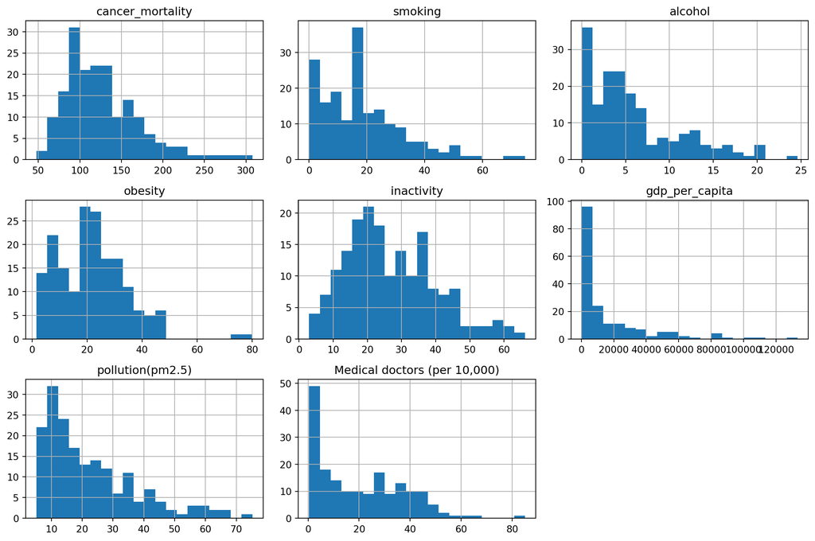

```python
import matplotlib.pyplot as plt

features = df.drop(columns=["country"])

features.hist(bins=20, figsize=(12,8))

plt.tight_layout()
plt.show()
```

Most variables show some degree of right-skewness, meaning many countries cluster around lower or moderate values while a smaller group sits much higher. This pattern is strongest for GDP per capita, which reflects large economic differences across countries. Smoking, alcohol consumption, pollution, and physician density also vary widely, suggesting that the countries in the dataset are far from homogeneous.

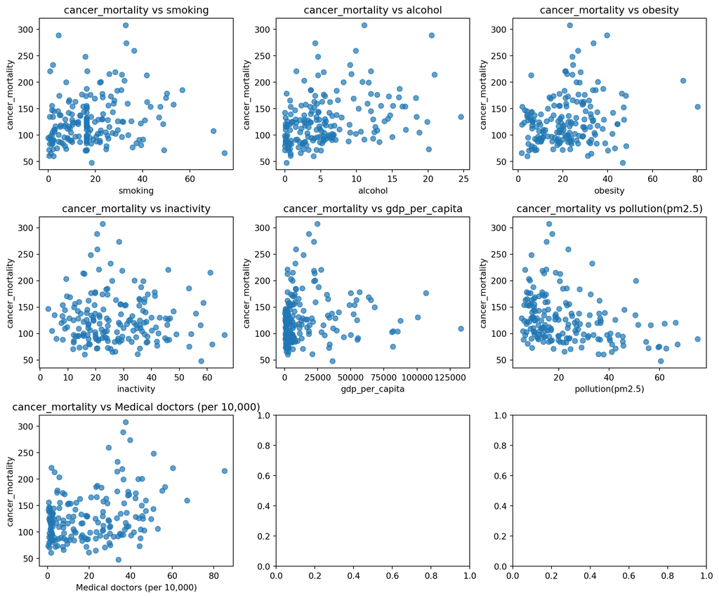

```python
target = "cancer_mortality"
features = df.drop(columns=["country", target]).columns

fig, axes = plt.subplots(3, 3, figsize=(12,10))
axes = axes.flatten()

for i, col in enumerate(features):
    axes[i].scatter(df[col], df[target], alpha=0.7)
    axes[i].set_xlabel(col)
    axes[i].set_ylabel(target)
    axes[i].set_title(f"{target} vs {col}")

plt.tight_layout()
plt.show()
```

The scatterplots suggest weak to moderate relationships overall, with substantial variability in nearly every panel. This is fairly typical for country-level public health data: cancer mortality is unlikely to be explained by any single predictor on its own.

Smoking, obesity, and alcohol consumption show slight upward trends, but the patterns are noisy rather than strong. GDP per capita, on the other hand, does not show a clear decreasing relationship with cancer mortality. One possible explanation is that wealthier countries may have better healthcare systems but also older populations, which can raise cancer risk and offset part of that advantage.

let’s exam the correlation matrix:

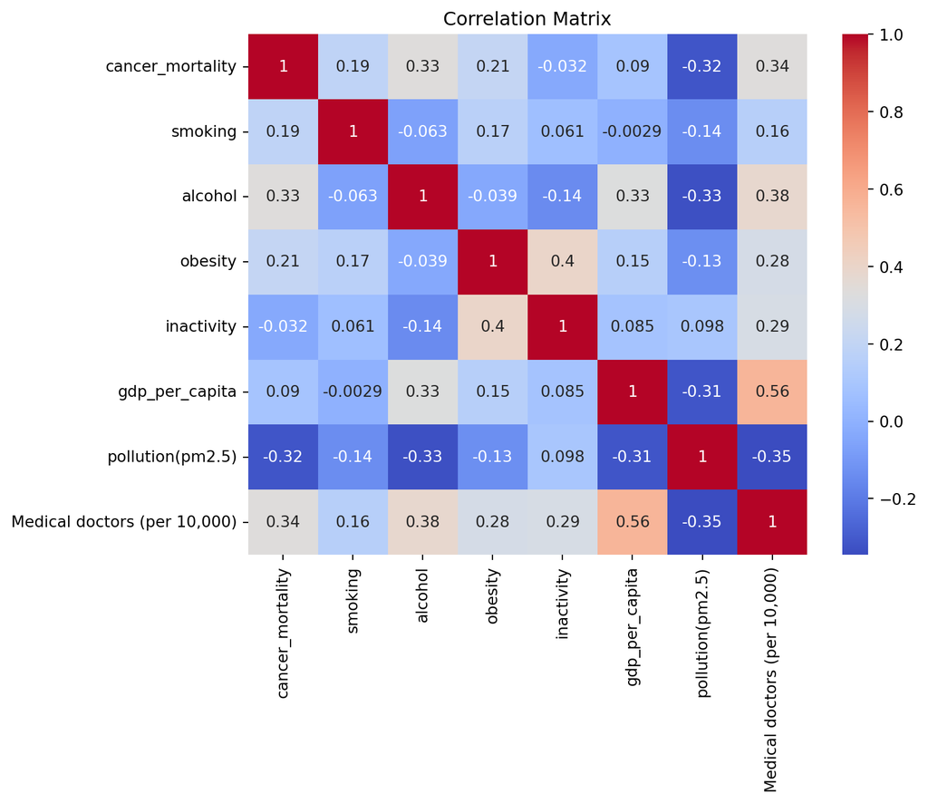

```python
import seaborn as sns

corr = df.drop(columns=["country"]).corr()

plt.figure(figsize=(8,6))
sns.heatmap(corr, annot=True, cmap="coolwarm")
plt.title("Correlation Matrix")
plt.show()
```

The correlation matrix tells a similar story. Correlations between cancer mortality and individual predictors are generally weak, although smoking, alcohol consumption, and obesity do show small positive associations. This suggests that the outcome is probably shaped by multiple factors at once rather than one dominant variable.

Some stronger relationships appear among the predictors themselves. GDP per capita is positively associated with physician density, which makes sense because wealthier countries often have greater healthcare capacity. Obesity and physical inactivity also show a moderate relationship, suggesting that these behaviors may cluster together across countries.

One result that stands out is the negative correlation between PM2.5 and cancer mortality. That is probably not a literal protective effect. More likely, it reflects confounding from broader cross-country differences such as life expectancy, age structure, and reporting quality.

next, boxplot for outlier inspection.

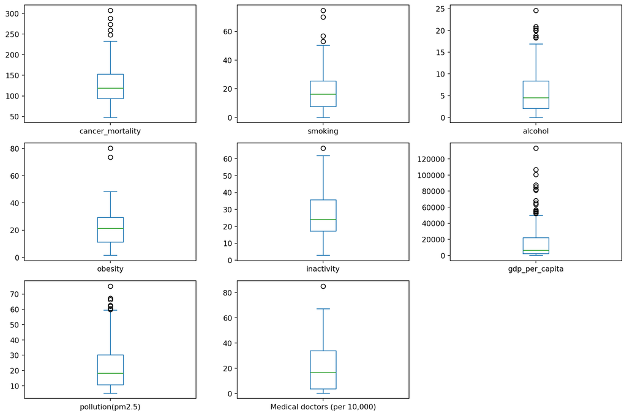

```python
df.drop(columns=["country"]).plot(
    kind="box",
    subplots=True,
    layout=(3,3),
    figsize=(12,8),
    sharex=False
)

plt.tight_layout()
plt.show()
```

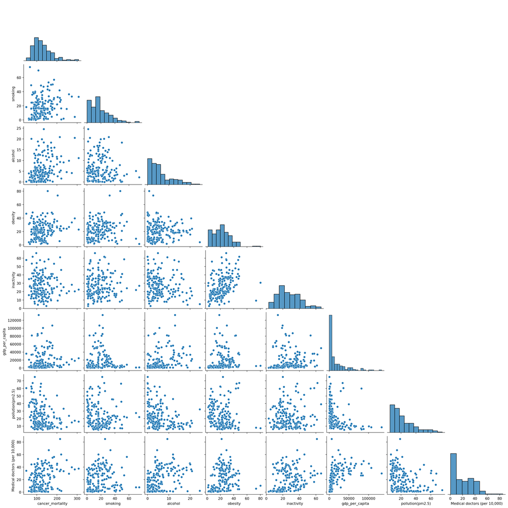

```python
sns.pairplot(
df.drop(columns=["country"]),
diag_kind="hist",
corner=True
) # well we do have alot of numeric feature so is messy...
#later for ml we might consider make some of them ordinal like gdp... if not we need to log it(dep on model fam).
```

## Summary

So far, the exploratory analysis suggests that cancer mortality differs a lot across countries, but no single predictor explains that variation especially well on its own. Smoking, alcohol consumption, and obesity all show weak positive relationships with cancer mortality, which is directionally reasonable, but the effects are noisy and clearly incomplete.

There are also a few patterns that are interesting precisely because they are not what I first expected. PM2.5, for example, shows a negative correlation with cancer mortality in this dataset. That is unlikely to be a real protective relationship, and is more plausibly a sign of confounding from broader cross-country differences such as life expectancy, healthcare access, and reporting quality. GDP per capita also does not show a simple protective pattern, which again suggests that the country-level story is more complicated than a one-variable explanation.

For the final project, I plan to move from exploratory analysis to predictive modeling. I will begin with a baseline linear model for interpretability, then compare it with more flexible models such as random forests and possibly gradient boosting. I will also consider feature transformations, especially log-scaling for skewed variables like GDP, and check whether imputation choices meaningfully affect model performance.

Beyond the modeling itself, the final project will include an interactive dashboard or small website so that users can explore the data more directly. The idea is to let someone inspect countries, compare predictor values, and possibly enter hypothetical country characteristics to generate a predicted cancer mortality rate. That would make the analysis more interpretable and a bit more engaging than a static report alone.